# Testing for COVID-19 by week and country_Europe

2020170837 최원준

2020-12-29

# Setup

```r
#install.packages("ggplot2")
library(ggplot2)
#install.packages("dplyr")
library(dplyr)
#install.packages('hrbrthemes')
library(hrbrthemes)
theme_set(theme_bw())
theme_set(theme_classic())

setwd('C:/Users/migre/OneDrive/데이터분석을 위한 프로그래밍언어/과제/A5')
covid_total <- read.csv("data.csv")
covid <- covid_total %>% filter(country %in% c('United Kingdom', 'Germany', 'France', 'Spain', 'Belgium', 'Italy'))
```

# 10 Graphs of the Data

**Population by Country**

유럽 30개 국가의 나라 별 인구 수를 알 수 있다. 앞으로의 8개의 그래프를 통해 알아볼 나라별 코로나 검사, 양성판정 수에 앞서 나라별 인구수라는 기본 정보에 대해 알 수 있다. 그래프를 통해 프랑스, 독일, 이탈리아, 영국 등의 인구가 매우 많음을 알 수 있엇고 인구수가 많은 나라와 적은 나라 간의 차이가 크고 중간이 거의 없음을 알 수 있다.

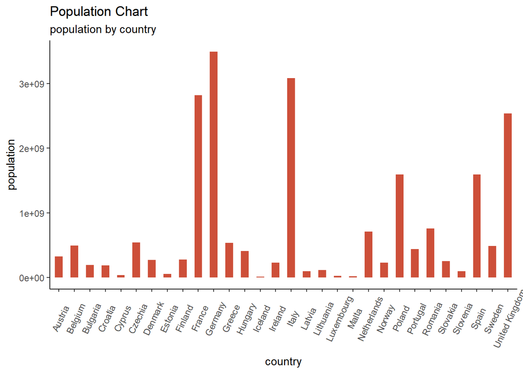

```r
ggplot(covid_total, aes(x=country, y=population)) +
  geom_bar(stat="identity", width=.5, fill="tomato3") +
  labs(title="Population Chart",
       subtitle="population by country") +
  theme(axis.text.x = element_text(angle=65, vjust=0.6))
```

**Population by Country(2)**

그래프1과 다르게 이번에는 나라별 인구수를 파이 그래프를 통해 표현해보았다. 여전히 프랑스, 독일, 영국, 스페인, 이탈리아 등의 나라가 큰 파이를 차지하고 나머지 나라들과의 차이도 매우 큼을 알 수 있다.

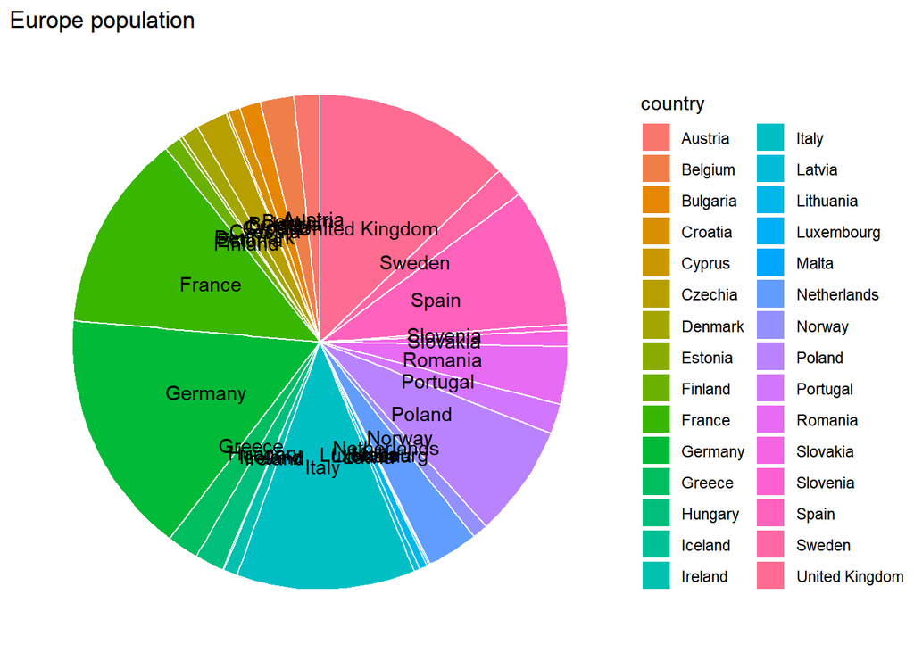

```r
covid_pop <- covid_total %>%
  select(c(country, population)) %>%
  unique

ggplot(covid_pop, aes(x='', y=population, fill = country))+
  geom_bar(width=1, stat = 'identity', color = 'white')+
  coord_polar('y') +
  geom_text(aes(label = country),
            position = position_stack(vjust = 0.5))+
  theme_void()+
  labs(title="Europe population")
```

**Sum of New Cases**

데이터를 수집한 기간 동안 나라별 확진자 수의 총합을 나타내는 막대그래프이다. 이때 주별로 색깔이 다르게 표시되지만 시각적 혼란을 주지 않기 위해 그라이데이션 형태로 만들었다. 그래프의 대략적인 개형이 1번에서 만든 인구수 막대그래프와 유사하다. 이를 통해 확진자 수와 인구수가 비슷한 비율로 생김을 알 수 있다.

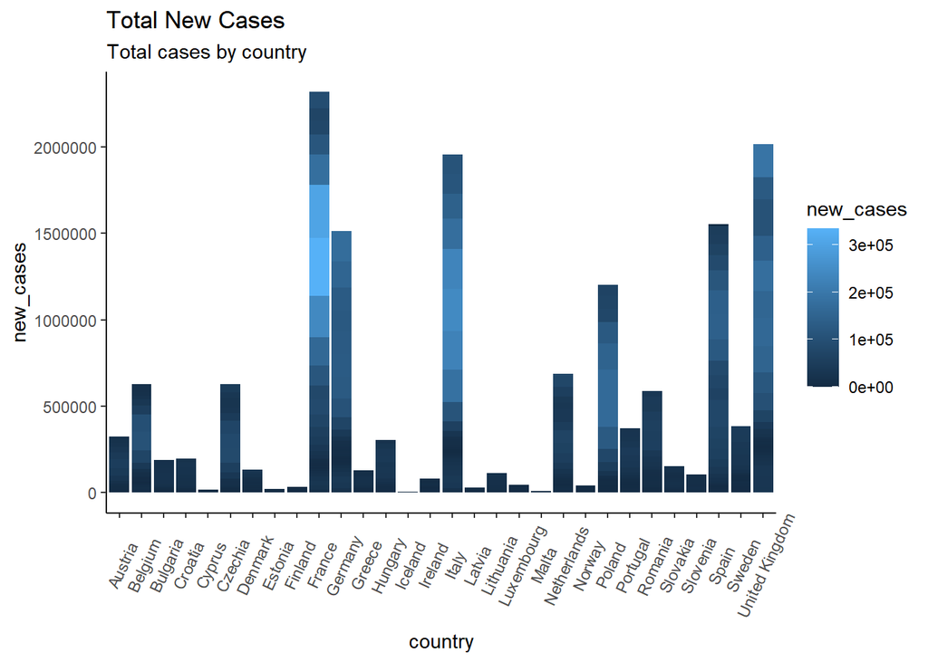

```r
ggplot(covid_total, aes(x=country, y=new_cases, fill=new_cases)) +
  geom_bar(stat="identity")+
  labs(title="Total New Cases",
     subtitle="Total cases by country") +
  theme(axis.text.x = element_text(angle=65, vjust=0.6))
```

**New Cases by time in United Kingdom**

데이터 수집 기간 동안 영국에서 발생한 확진자 수를 나타낸 그래프다. 잠시 확진자 수가 감소했다가 매우 증가하는 형태를 가진다. 이는 아마 영국뿐만 아니라 대부분의 유럽 나라가 비슷한 형태를 가질 것으로 예측된다.

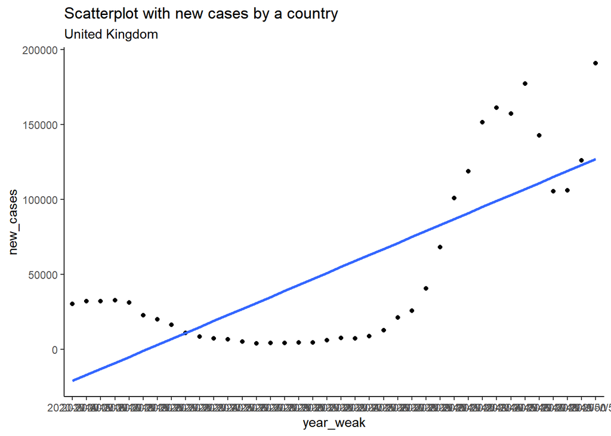

```r
covid_uk <- covid %>% filter(country == 'United Kingdom')

ggplot(covid_uk, aes(x=year_week, y=new_cases, group=1))+
  geom_point() +
  geom_smooth(method="lm", se=F) +
  labs(subtitle="United Kingdom",
       y="new_cases",
       x="year_weak",
       title="Scatterplot with new cases by a country")
```

**Box plot of positivity rate**

box plot은 데이터의 분포를 직사각형 상자 모양으로 표현한 그래프다. 이 그래프를 통해 평균만 볼 때보다는 조금 더 데이터의 특징을 자세히 알 수 있다.

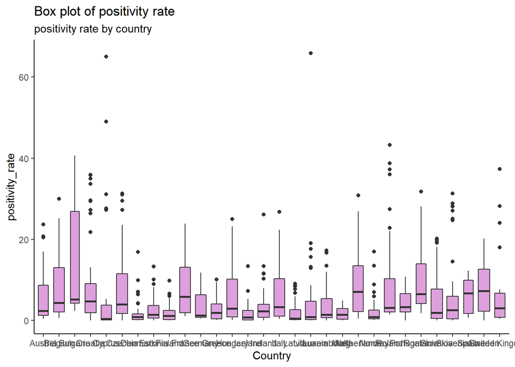

```r
ggplot(covid_total, aes(country, positivity_rate))+
  geom_boxplot(varwidth=T, fill="plum") +
  labs(title="Box plot of positivity rate",
       subtitle="positivity rate by country",
       x="Country",
       y="positivity_rate")
```

**Sorted positivity rate by country**

이 그래프는 각 나라별 positivity rate의 평균을 sort하여 오름차순으로 그린 것이다. 이때 positivity rate는 100 x Number of new confirmed cases/number of tests done per week로 구하므로 이의 평균은 나라별 전체적인 확진률을 나타낸다. 인구수와 상관없이 나라별로 얼마나 코로나가 위험하게 전파되고 있는지를 알 수 있다. 이에 따라 인구의 많고 적음과는 별개로 불가리아. 로마니아, 폴란드, 네덜란드, 크로아티아 등이 매우 위험한 상황임을 알 수 있다. 또한 인구수와 확진자수 그래프와는 다르게 나라별 수치가 촘촘하다는 점을 알 수 있다.

```r
covid5 <- covid_total %>%
  group_by(country) %>%
  summarise(positivity_rate_avg = mean(positivity_rate, na.rm=TRUE))
```

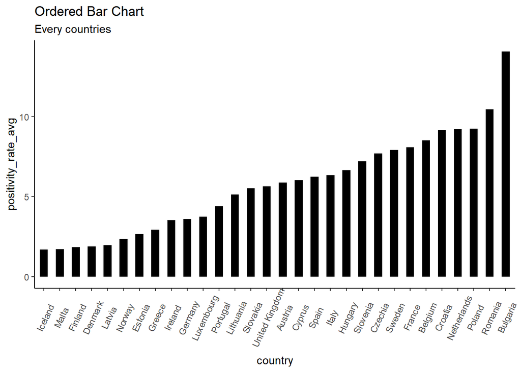

```r
covid5 <- covid5[order(covid5$positivity_rate_avg), ]
covid5$country <- factor(covid5$country, levels = covid5$country)

ggplot(covid5, aes(x=country, y=positivity_rate_avg)) +
  geom_bar(stat="identity", width=.5, fill="black") +
  labs(title="Ordered Bar Chart",
       subtitle="Every countries") +
  theme(axis.text.x = element_text(angle=65, vjust=0.6))
```

**Tests done and new cases in France**

이 그래프에서는 프랑스에서의 코로나 검사수와 확진자 수에 대해서 표현을 하였다. 검사 수를 나타내는 직선이 파란색이고 확진자 수를 나타내는 직선이 빨간색이다. 후반에 갈 수록 확진자 수에 비해 검사 수가 훨씬 증가하는 것을 보면 확진 외에도 확진자가 접촉을 한 사람이나 코로나에 대한 불안으로 인해 검사를 더 많이 받았음을 알 수 있다.

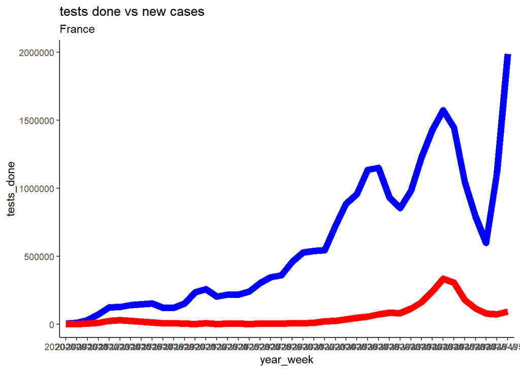

```r
covid_fr <- covid %>%
  filter(country == 'France')

ggplot(covid_fr, aes(x=year_week, y=tests_done, group=1))+
  geom_line(color="blue", size=3)+
  geom_line(aes(x=year_week,y=new_cases, group=1), color="red", size=3)+
  labs(title="tests done vs new cases",
        subtitle="France")
```

**Positivity rate of six countries(France, Germany, UK, Spain, Belgium, Italy)**

나라별 확진율이 시간이 지남에 따라 어떻게 변했는지를 보여주는 그래프이다. 나라가 너무 많아서 프랑스, 독일, 스페인, 벨기에, 이탈리아, 영국 여섯 나라들의 수치많을 보여주었다. 작은 차이들은 있지만 여섯 나라의 확진율 증감 추이는 거의 비슷함을 알 수 있다. 이를 통해 유럽 내에서는 나라끼리 서로가 서로에게 코로나 영향을 준다는 것을 추측해볼 수 있다.

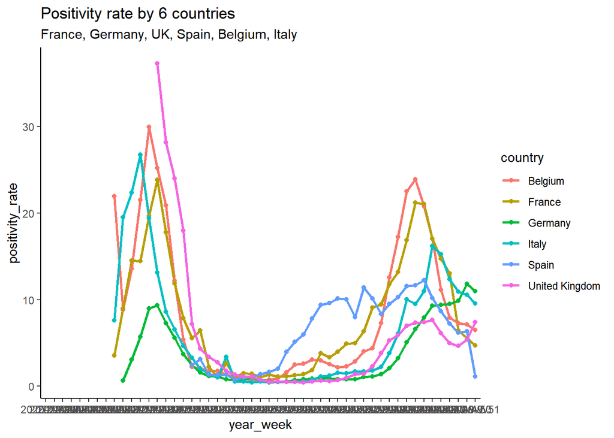

```r
ggplot(covid, aes(x=year_week, y=positivity_rate, color=country, group=country))+
  geom_line(size=1)+
  geom_point()+
  labs(title='Positivity rate by 6 countries',
       subtitle = 'France, Germany, UK, Spain, Belgium, Italy')
```

**Ratio between sum of new cases and population**

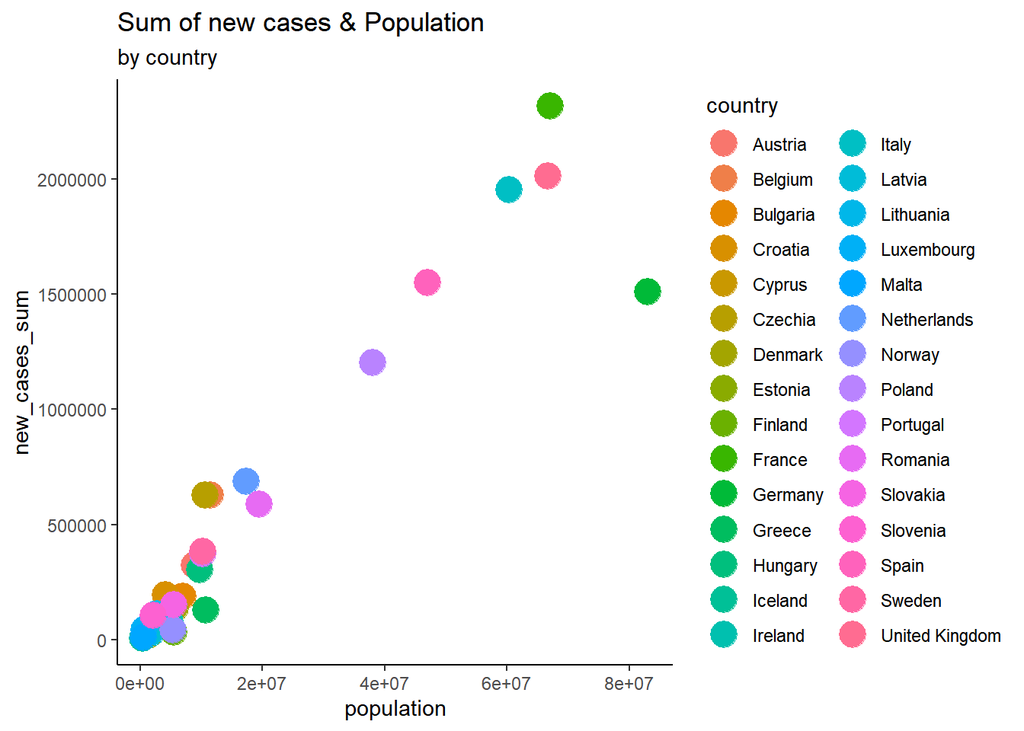

```r
covid8 <- covid_total %>%
  group_by(country) %>%
  mutate(new_cases_sum = sum(new_cases)) %>%
  select(c(country, new_cases_sum, population)) %>%
  unique

ggplot(covid8, aes(x=population, y=new_cases_sum, color=country)) +
  geom_point(size=6) +
  labs(title="Sum of new cases & Population",
       subtitle="by country")
```

**Average of positivity rate by week**

이 그래프는 위에서 구했던 나라별 확진율의 평균과 같이 날짜별 모든 나라의 확진율 평균을 그래프로 나타낸 것이다. 이 그래프를 통해 n차 대유행을 정의할 수 있을 것이고 평균의 증감이 큰 것을 보아 나라별 확진율 평균의 차이가 크지 않다는 것을 알 수 있다.

```r
covid10 <- covid_total %>%
  group_by(year_week) %>%
  summarise(pos_rate_avg = mean(positivity_rate, na.rm=TRUE))
```

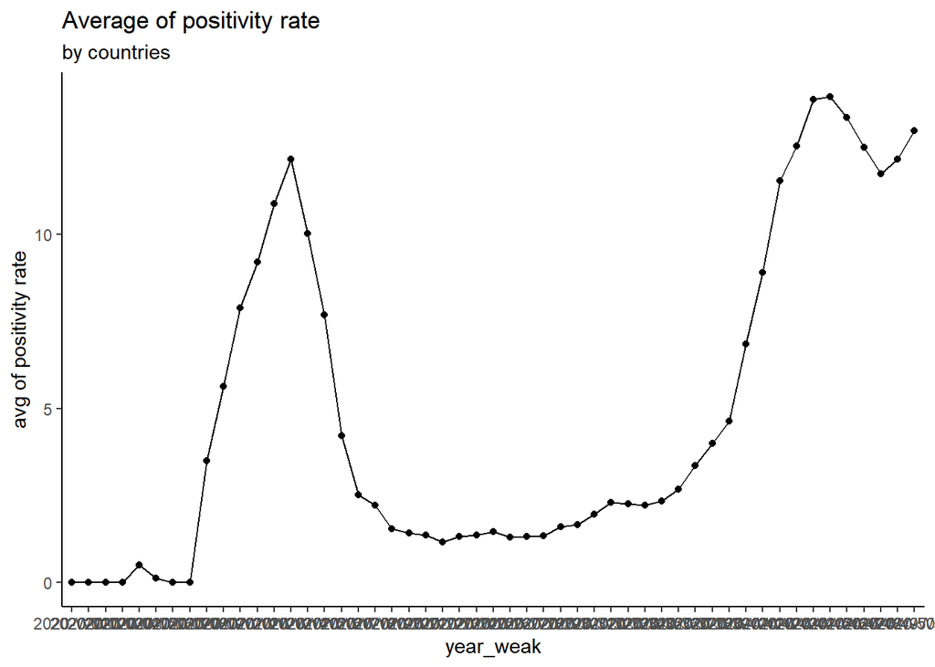

```r
ggplot(covid10, aes(x=year_week, y = pos_rate_avg, group=1))+
  geom_point()+
  geom_line()+
  labs(title= 'Average of positivity rate',
       subtitle="by countries",
       y="avg of positivity rate",
       x="year_weak")
```